# US Medical School & Health System AI Guidelines — Descriptive Analysis

Run 24 (R analysis v2)

2026-09-17

## Setup

All figures are derived exclusively from `analysis/clauses.csv` (documents × 13 columns), read with `utils::read.csv`. Blank cells count as absent. No other data source is consulted; no numbers are imputed.

Note (run 24): figures 6–7 aggregate by named institution; `org` strings that belong to the same university (e.g. “Harvard Medical School IT” and “Harvard University”) are grouped via the match patterns defined in the Figure 6 chunk.

```r
library(tidyverse)
library(ggsci)
library(lubridate)
theme_set(theme_minimal(base_size = 12) +
          theme(plot.title.position = "plot",
                plot.caption.position = "plot",
                legend.position = "bottom"))
```

```r
# path robust to whether knitr's root is analysis/ or the repo root
csv_path <- if (file.exists("clauses.csv")) "clauses.csv" else "analysis/clauses.csv"
clauses <- utils::read.csv(csv_path,
                           stringsAsFactors = FALSE, na.strings = c("NA"))
n_docs <- nrow(clauses)

# ---- derivations (all from CSV cells; blank == absent) ----

# year from effective_date; extract first 4-digit year token, keep only 202x
clauses <- clauses %>%
  mutate(
    year_chr   = str_extract(trimws(as.character(effective_date)), "\\d{4}"),
    year       = suppressWarnings(as.integer(year_chr)),
    year       = if_else(!is.na(year) & year >= 2020 & year <= 2026, year, NA_integer_),
    # formal policy vs guidance: formal policy & handbook are prescriptive;
    # guidance & curricular are advisory
    doc_group  = case_when(
      doc_type %in% c("formal policy", "handbook section") ~ "formal policy / handbook",
      doc_type %in% c("guidance", "curricular")           ~ "guidance / curricular",
      TRUE                                                 ~ NA_character_
    ),
    sector     = case_when(
      str_detect(applies_to, regex("clinician|resident|fellow|VUMC|health-system|CME", ignore_case = TRUE)) &
        !str_detect(applies_to, regex("student|faculty|trainee|PA |instructor", ignore_case = TRUE)) ~ "Health system / GME-clinical",
      str_detect(applies_to, regex("student|trainee|learner|curriculum", ignore_case = TRUE)) |
        doc_type %in% c("curricular") ~ "UME (learners)",
      !is.na(applies_to) & trimws(applies_to) != "" ~ "Mixed / other",
      TRUE ~ NA_character_
    ),
    has_banned    = trimws(as.character(banned_uses))       != "",
    has_tool      = trimws(as.character(secure_tools_named)) != "",
    has_phi       = trimws(as.character(phi_rule))          != "",
    has_disclosure= trimws(as.character(disclosure_rule))   != "",
    has_enforce   = trimws(as.character(enforcement))       != "",
    has_assess    = trimws(as.character(assessment_rule))   != "",
    aamc_yes      = str_detect(tolower(as.character(aamc_alignment)), "^yes"),
    phi_hipaa     = has_phi & str_detect(phi_rule, regex("hipaa|phi", ignore_case = TRUE)),
    phi_baa       = has_phi & str_detect(phi_rule, regex("business associate|\\bbaa\\b", ignore_case = TRUE)),
    phi_prohibit  = has_phi & str_detect(phi_rule, regex("never|not be (entered|input|exposed|used)|may not|prohibit|do not post|violation", ignore_case = TRUE)),
    phi_deid      = has_phi & str_detect(phi_rule, regex("de-?identif|sanitiz", ignore_case = TRUE)),
    phi_approv    = has_phi & str_detect(phi_rule, regex("approved|enterprise|hipaa compliant|hipAA certified|contract|sensitive data|approved for", ignore_case = TRUE))
  )
```

Dataset: **274** documents, 230 distinct organizations.

```r
clauses %>% count(doc_type, doc_group) %>% knitr::kable()
```

| doc_type | doc_group | n |
| --- | --- | --- |
| curricular | guidance / curricular | 10 |
| formal policy | formal policy / handbook | 58 |
| guidance | guidance / curricular | 193 |
| handbook section | formal policy / handbook | 13 |

```r
clauses %>% count(sector) %>% knitr::kable()
```

| sector | n |
| --- | --- |
| Health system / GME-clinical | 42 |
| Mixed / other | 18 |
| UME (learners) | 206 |
| NA | 8 |

## Figure 1 — Adoption timeline by year and document type

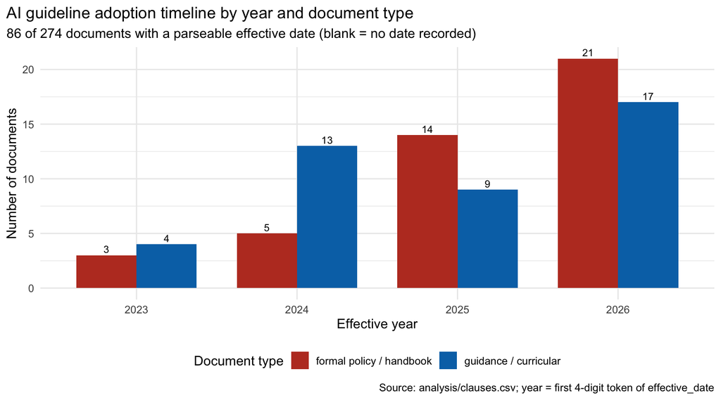

```r
f1 <- clauses %>%
  filter(!is.na(year)) %>%
  count(year, doc_group) %>%
  ggplot(aes(x = factor(year), y = n, fill = doc_group)) +
  geom_col(position = position_dodge(preserve = "single"), width = 0.75) +
  geom_text(aes(label = n),
            position = position_dodge(width = 0.75), vjust = -0.35, size = 3.2) +
  scale_fill_nejm(name = "Document type") +
  labs(
    title = "AI guideline adoption timeline by year and document type",
    subtitle = sprintf("%d of %d documents with a parseable effective date (blank = no date recorded)",
                       sum(!is.na(clauses$year)), n_docs),
    x = "Effective year", y = "Number of documents",
    caption = "Source: analysis/clauses.csv; year = first 4-digit token of effective_date"
  )
f1
```

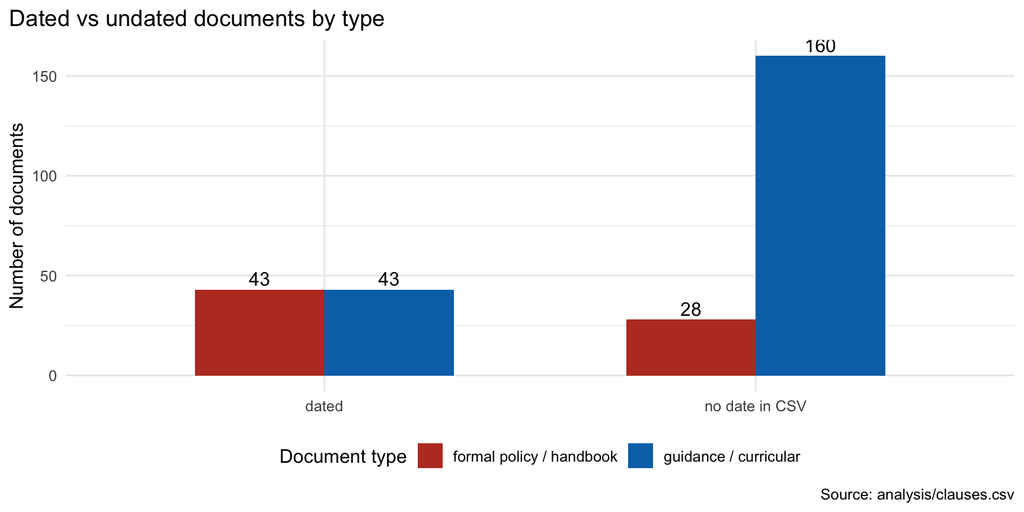

```r
# Sensitivity view: undated documents shown as "no date", by doc group
clauses %>%
  mutate(dated = if_else(is.na(year), "no date in CSV", "dated")) %>%
  count(dated, doc_group) %>%
  ggplot(aes(x = dated, y = n, fill = doc_group)) +
  geom_col(position = position_dodge(preserve = "single"), width = 0.6) +
  geom_text(aes(label = n), position = position_dodge(width = 0.6), vjust = -0.3) +
  scale_fill_nejm(name = "Document type") +
  labs(title = "Dated vs undated documents by type",
       x = NULL, y = "Number of documents",
       caption = "Source: analysis/clauses.csv")
```

## Figure 2 — Banned-use themes (overall + UME vs health-system split)

Themes are keyword patterns applied to the `banned_uses` free text; a document counts toward a theme if any keyword matches (blank cells never match).

```r
theme_patterns <- c(
  "PHI / patient data into AI"  = "phi\\b|patient|hipaa|identifiable",
  "Graded work / exams"         = "exam|graded|grade |assessment|quiz|proctored|assignment",
  "Plagiarism / passing off AI work as own" = "plagiar|one's own|as own|original|misrepresent",
  "Clinical documentation"      = "note|documentation|h&p|progress note|ehr",
  "Unapproved / public tools"   = "unapproved|non-approved|not approved|unapproved|public tool|public or non",
  "Confidential / institutional data" = "confidential|institutional data|university data|sensitive information|student records"
)
has_any <- function(x, pattern) !is.na(x) & str_detect(x, regex(pattern, ignore_case = TRUE))

theme_long <- imap_dfr(theme_patterns, function(p, nm) {
  clauses %>% transmute(org, sector, hit = has_any(banned_uses, p)) %>%
    mutate(theme = nm)
})
theme_summary <- theme_long %>%
  group_by(theme) %>%
  summarise(overall = sum(hit), .groups = "drop") %>%
  mutate(pct = sprintf("%d%%", round(100 * overall / n_docs))) %>%
  arrange(desc(overall))
theme_summary %>% knitr::kable()
```

| theme | overall | pct |
| --- | --- | --- |
| PHI / patient data into AI | 44 | 16% |
| Graded work / exams | 43 | 16% |
| Confidential / institutional data | 39 | 14% |
| Unapproved / public tools | 23 | 8% |
| Clinical documentation | 17 | 6% |
| Plagiarism / passing off AI work as own | 14 | 5% |

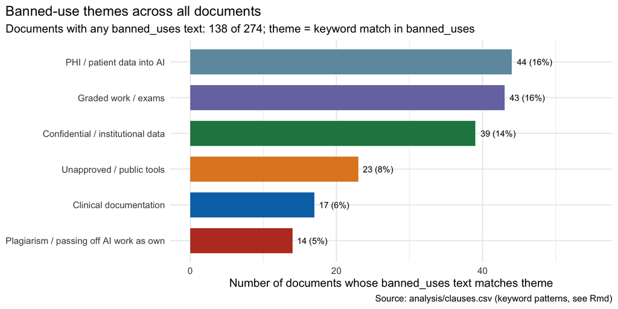

```r
f2a <- theme_summary %>%
  mutate(theme = fct_reorder(theme, overall)) %>%
  ggplot(aes(x = overall, y = theme)) +
  geom_col(aes(fill = theme), show.legend = FALSE, width = 0.7) +
  geom_text(aes(label = paste0(overall, " (", pct, ")")), hjust = -0.15, size = 3.2) +
  scale_fill_nejm() +
  expand_limits(x = max(theme_summary$overall) * 1.25) +
  labs(
    title = "Banned-use themes across all documents",
    subtitle = sprintf("Documents with any banned_uses text: %d of %d; theme = keyword match in banned_uses",
                       sum(clauses$has_banned), n_docs),
    x = "Number of documents whose banned_uses text matches theme",
    y = NULL,
    caption = "Source: analysis/clauses.csv (keyword patterns, see Rmd)"
  )
f2a
```

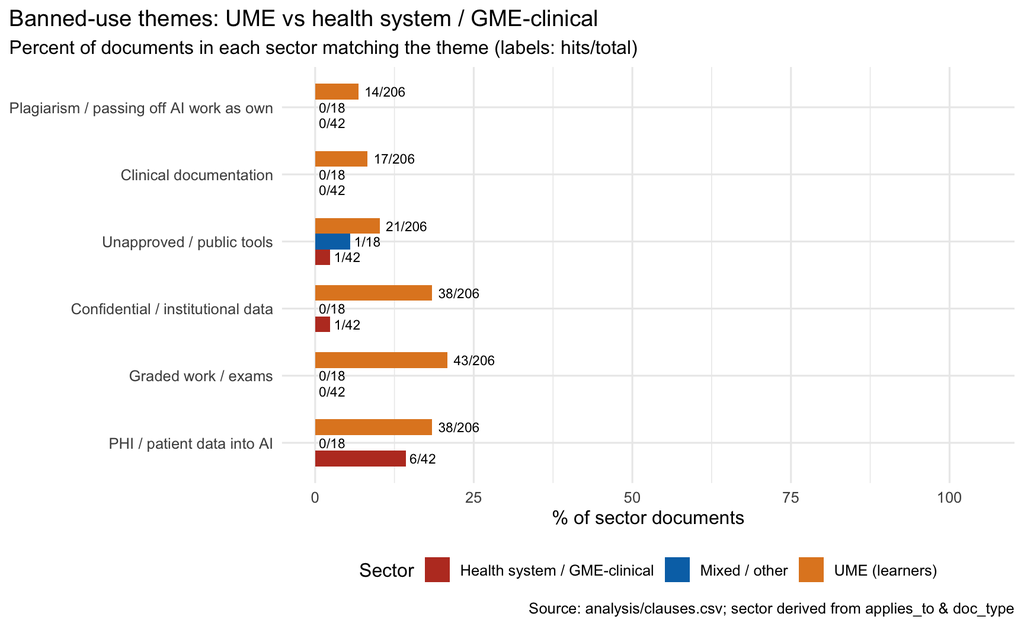

```r
split_summary <- theme_long %>%
  filter(!is.na(sector)) %>%
  group_by(theme, sector) %>%
  summarise(n_hit = sum(hit), n_tot = n(), .groups = "drop_last") %>%
  mutate(pct = 100 * n_hit / n_tot)

f2b <- split_summary %>%
  mutate(theme = factor(theme, levels = theme_summary$theme)) %>%
  ggplot(aes(x = pct, y = theme, fill = sector)) +
  geom_col(position = position_dodge(preserve = "single"), width = 0.7) +
  geom_text(aes(label = paste0(n_hit, "/", n_tot)),
            position = position_dodge(width = 0.7), hjust = -0.15, size = 3) +
  scale_fill_nejm(name = "Sector") +
  expand_limits(x = 105) +
  labs(
    title = "Banned-use themes: UME vs health system / GME-clinical",
    subtitle = "Percent of documents in each sector matching the theme (labels: hits/total)",
    x = "% of sector documents", y = NULL,
    caption = "Source: analysis/clauses.csv; sector derived from applies_to & doc_type"
  )
f2b
```

## Figure 3 — PHI clause presence and language clusters

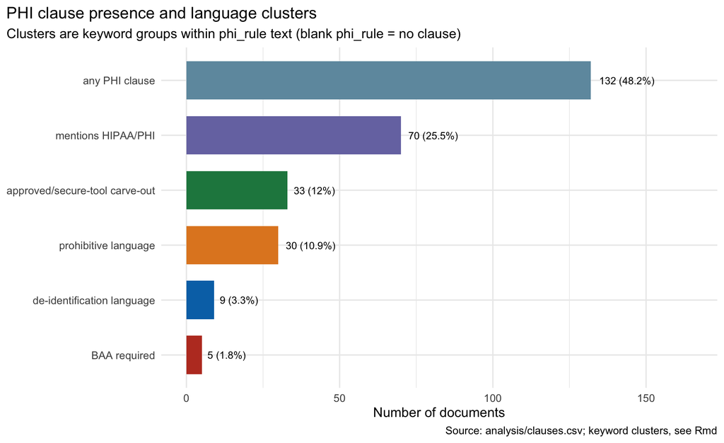

```r
phi_tbl <- tibble(
  cluster = c("any PHI clause", "mentions HIPAA/PHI", "prohibitive language",
              "approved/secure-tool carve-out", "BAA required", "de-identification language"),
  n = c(sum(clauses$has_phi), sum(clauses$phi_hipaa), sum(clauses$phi_prohibit),
        sum(clauses$phi_approv), sum(clauses$phi_baa), sum(clauses$phi_deid))
) %>%
  mutate(pct = round(100 * n / n_docs, 1),
         cluster = fct_reorder(cluster, n))

f3 <- phi_tbl %>%
  ggplot(aes(x = n, y = cluster)) +
  geom_col(aes(fill = cluster), show.legend = FALSE, width = 0.7) +
  geom_text(aes(label = paste0(n, " (", pct, "%)")), hjust = -0.15, size = 3.2) +
  scale_fill_nejm() +
  expand_limits(x = max(phi_tbl$n) * 1.25) +
  labs(
    title = "PHI clause presence and language clusters",
    subtitle = "Clusters are keyword groups within phi_rule text (blank phi_rule = no clause)",
    x = "Number of documents", y = NULL,
    caption = "Source: analysis/clauses.csv; keyword clusters, see Rmd"
  )
f3
```

## Figure 4 — Named secure tools

[figure not shown]

```r
tool_patterns <- c(
  "ChatGPT"        = "\\bchatgpt|gpt-5|gpt-4|openai",
  "Microsoft Copilot" = "copilot",
  "Claude"         = "claude|anthropic",
  "Gemini"         = "gemini",
  "Grammarly"      = "grammarly",
  "NotebookLM"     = "notebooklm",
  "Azure OpenAI"   = "azure",
  "Zoom AI"        = "zoom ai",
  "Abridge"        = "abridge",
  "institutional custom tool" = "dartmouthchat|terrier gpt|aichat|sc ai|scai|gpt\\s*\\("
)
tool_long <- imap_dfr(tool_patterns, function(p, nm) {
  tibble(tool = nm,
         hit = sum(has_any(clauses$secure_tools_named, p)))
})
f4 <- tool_long %>%
  mutate(tool = fct_reorder(tool, hit)) %>%
  ggplot(aes(x = hit, y = tool)) +
  geom_col(aes(fill = tool), show.legend = FALSE, width = 0.7) +
  geom_text(aes(label = hit), hjust = -0.2, size = 3.4) +
  scale_fill_nejm() +
  expand_limits(x = max(tool_long$hit) * 1.15) +
  labs(
    title = "Named secure tools in AI guideline documents",
    subtitle = sprintf("Documents naming any tool in secure_tools_named: %d of %d",
                       sum(clauses$has_tool), n_docs),
    x = "Number of documents naming the tool", y = NULL,
    caption = "Source: analysis/clauses.csv (keyword match, case-insensitive)"
  )
f4
```

## Figure 5 — Disclosure / enforcement / AAMC alignment, UME vs HS

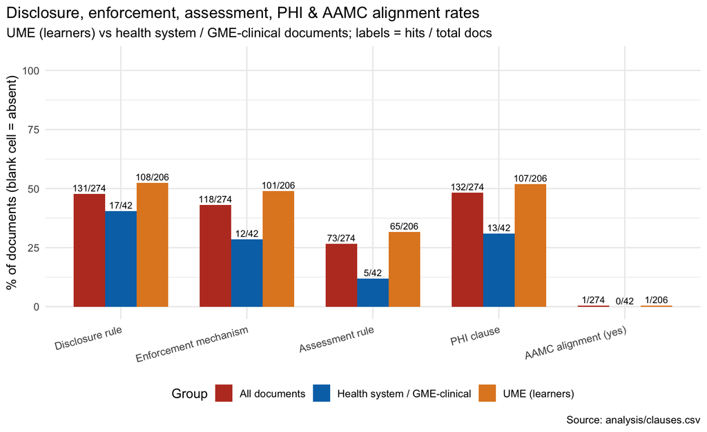

```r
rate_rows <- function(df) {
  tibble(
    metric = c("Disclosure rule", "Enforcement mechanism", "Assessment rule",
               "PHI clause", "AAMC alignment (yes)"),
    n = c(sum(df$has_disclosure), sum(df$has_enforce), sum(df$has_assess),
          sum(df$has_phi), sum(df$aamc_yes)),
    N = nrow(df)
  ) %>% mutate(pct = round(100 * n / N, 1))
}
rates <- bind_rows(
  rate_rows(clauses %>% filter(sector == "UME (learners)"))      %>% mutate(group = "UME (learners)"),
  rate_rows(clauses %>% filter(sector == "Health system / GME-clinical")) %>% mutate(group = "Health system / GME-clinical"),
  rate_rows(clauses)                                             %>% mutate(group = "All documents")
) %>%
  mutate(metric = factor(metric, levels = c("Disclosure rule", "Enforcement mechanism",
                                            "Assessment rule", "PHI clause", "AAMC alignment (yes)")))

f5 <- rates %>%
  ggplot(aes(x = metric, y = pct, fill = group)) +
  geom_col(position = position_dodge(preserve = "single"), width = 0.75) +
  geom_text(aes(label = paste0(n, "/", N)),
            position = position_dodge(width = 0.75), vjust = -0.4, size = 3, angle = 0) +
  scale_fill_nejm(name = "Group") +
  expand_limits(y = 105) +
  labs(
    title = "Disclosure, enforcement, assessment, PHI & AAMC alignment rates",
    subtitle = "UME (learners) vs health system / GME-clinical documents; labels = hits / total docs",
    x = NULL, y = "% of documents (blank cell = absent)",
    caption = "Source: analysis/clauses.csv"
  ) +
  theme(axis.text.x = element_text(angle = 15, hjust = 1))
f5
```

## Figure 6 — Source coverage by named institution (top 30)

`org` strings are grouped to a parent institution via case-insensitive match patterns (applied in order, first match wins; unmatched orgs keep their raw name). Bars show the number of source documents per institution, top 30.

```r
# match patterns: named institution -> regex on org (case-insensitive)
school_patterns <- c(
  "Harvard"            = "^harvard",
  "Johns Hopkins"      = "johns hopkins",
  "Penn"               = "university of pennsylvania|perelman",
  "Columbia"           = "^columbia",
  "Stanford"           = "stanford",
  "UCSF"               = "^ucsf",
  "UCLA"               = "ucla",
  "WashU"              = "washington university",
  "Cornell"            = "cornell",
  "Michigan"           = "university of michigan|michigan medicine",
  "Michigan State"     = "michigan state",
  "Yale"               = "^yale",
  "Duke"               = "^duke",
  "Pitt"               = "university of pittsburgh|^upmc",
  "NYU"                = "^nyu",
  "Northwestern"       = "northwestern",
  "UChicago"           = "university of chicago",
  "Baylor"             = "baylor",
  "Emory"              = "emory",
  "Mayo"               = "mayo",
  "Case Western"       = "case western",
  "Icahn/Mount Sinai"  = "mount sinai",
  "UTHealth Houston"   = "uthealth|mcgovern"
)
```

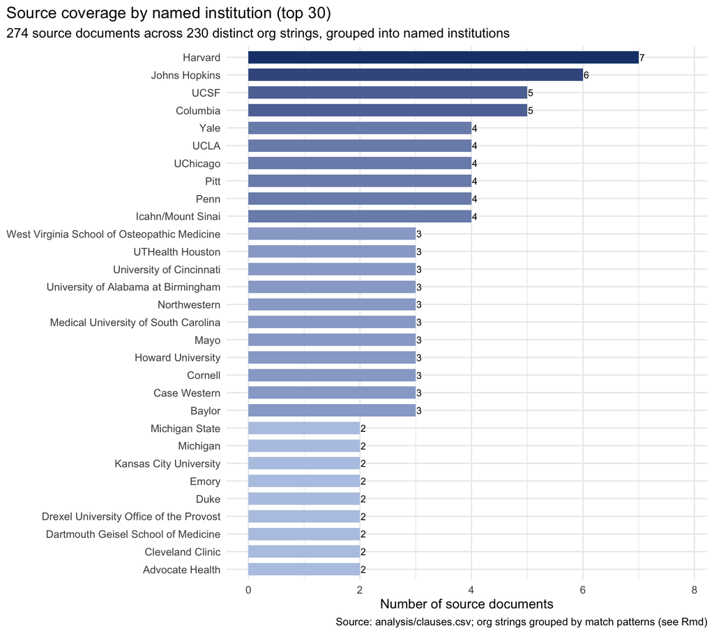

```r
map_school <- function(org) {
  for (nm in names(school_patterns)) {
    if (str_detect(tolower(org), school_patterns[[nm]])) return(nm)
  }
  org
}
school_counts <- clauses %>%
  mutate(institution = map_chr(as.character(org), map_school)) %>%
  count(institution, sort = TRUE) %>%
  slice_head(n = 30)

f6 <- school_counts %>%
  mutate(institution = fct_reorder(institution, n)) %>%
  ggplot(aes(x = n, y = institution)) +
  geom_col(aes(fill = n), show.legend = FALSE, width = 0.7) +
  geom_text(aes(label = n), hjust = -0.15, size = 3.1) +
  scale_fill_gradient(low = "#B6C7E4", high = "#1B4079") +
  expand_limits(x = max(school_counts$n) * 1.12) +
  labs(
    title = "Source coverage by named institution (top 30)",
    subtitle = sprintf("%d source documents across %d distinct org strings, grouped into named institutions",
                       n_docs, n_distinct(clauses$org)),
    x = "Number of source documents", y = NULL,
    caption = "Source: analysis/clauses.csv; org strings grouped by match patterns (see Rmd)"
  )
f6
```

## Figure 7 — Formal-policy adoption among top-20 research schools

Hardcoded top-20 list (USNews research-primary-care ranking basis, run 24 spec): Harvard, JHU, Penn, Columbia, Stanford, UCSF, UCLA, WashU, Cornell, Michigan, Yale, Duke, Pitt, NYU, Northwestern, UChicago, Baylor, Emory, Mayo, Case. Each school is matched against org names with the same patterns as Figure 6 and classified as **formal policy** if any matched document is `doc_type == "formal policy"` (or “handbook section”), else **guidance only**; schools with zero matched documents are shown as **not covered**.

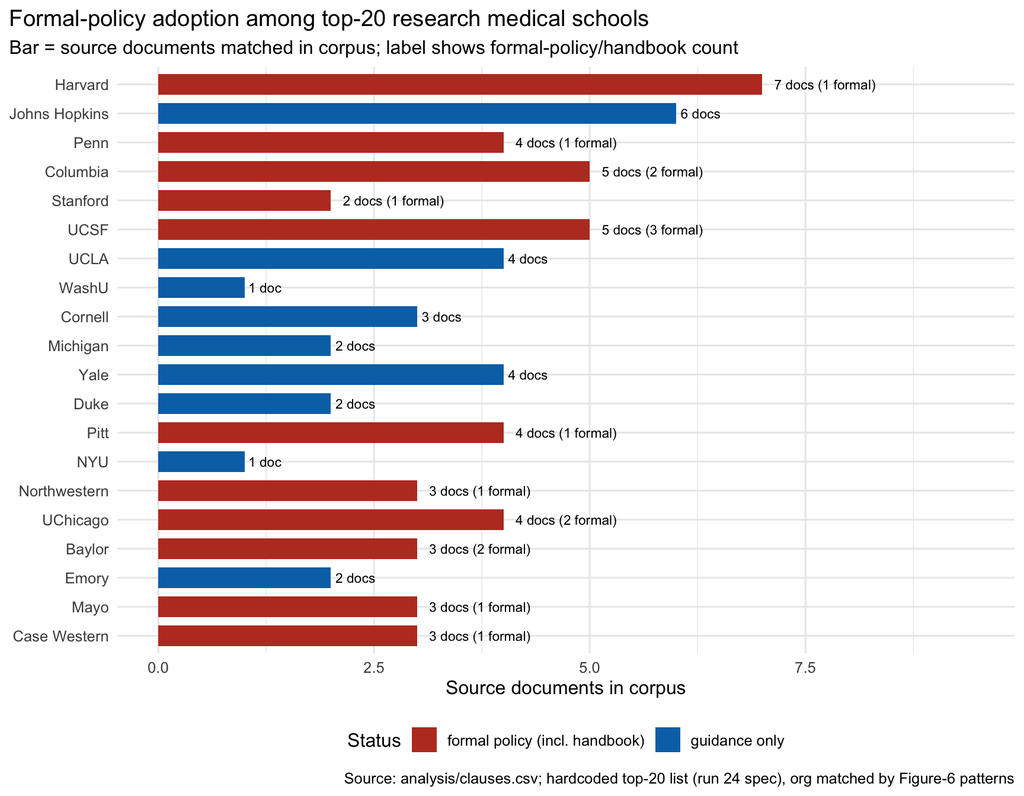

```r
top20 <- c("Harvard", "Johns Hopkins", "Penn", "Columbia", "Stanford", "UCSF",
           "UCLA", "WashU", "Cornell", "Michigan", "Yale", "Duke", "Pitt",
           "NYU", "Northwestern", "UChicago", "Baylor", "Emory", "Mayo",
           "Case Western")
# reuse Figure 6 patterns for the schools in the top-20 list
stopifnot(all(top20 %in% names(school_patterns)))

top20_status <- map_dfr(top20, function(s) {
  pat <- school_patterns[[s]]
  docs <- clauses %>% filter(str_detect(tolower(as.character(org)), pat))
  tibble(
    school = s,
    n_docs = nrow(docs),
    n_formal = sum(docs$doc_type %in% c("formal policy", "handbook section")),
    status = case_when(
      nrow(docs) == 0 ~ "not covered in corpus",
      nrow(docs) > 0 & n_formal > 0 ~ "formal policy (incl. handbook)",
      TRUE ~ "guidance only"
    )
  )
})

f7 <- top20_status %>%
  mutate(school = factor(school, levels = rev(top20)),
         status = factor(status, levels = c("formal policy (incl. handbook)",
                                            "guidance only",
                                            "not covered in corpus"))) %>%
  ggplot(aes(x = n_docs, y = school, fill = status)) +
  geom_col(width = 0.7) +
  geom_text(aes(label = paste0(n_docs, " doc", if_else(n_docs == 1, "", "s"),
                               if_else(n_formal > 0, paste0(" (", n_formal, " formal)"), ""))),
            hjust = -0.12, size = 3) +
  scale_fill_nejm(name = "Status") +
  expand_limits(x = max(top20_status$n_docs) * 1.35) +
  labs(
    title = "Formal-policy adoption among top-20 research medical schools",
    subtitle = "Bar = source documents matched in corpus; label shows formal-policy/handbook count",
    x = "Source documents in corpus", y = NULL,
    caption = "Source: analysis/clauses.csv; hardcoded top-20 list (run 24 spec), org matched by Figure-6 patterns"
  )
f7
```

```r
top20_status %>% knitr::kable()
```

| school | n_docs | n_formal | status |
| --- | --- | --- | --- |
| Harvard | 7 | 1 | formal policy (incl. handbook) |
| Johns Hopkins | 6 | 0 | guidance only |
| Penn | 4 | 1 | formal policy (incl. handbook) |
| Columbia | 5 | 2 | formal policy (incl. handbook) |
| Stanford | 2 | 1 | formal policy (incl. handbook) |
| UCSF | 5 | 3 | formal policy (incl. handbook) |
| UCLA | 4 | 0 | guidance only |
| WashU | 1 | 0 | guidance only |
| Cornell | 3 | 0 | guidance only |
| Michigan | 2 | 0 | guidance only |
| Yale | 4 | 0 | guidance only |
| Duke | 2 | 0 | guidance only |
| Pitt | 4 | 1 | formal policy (incl. handbook) |
| NYU | 1 | 0 | guidance only |
| Northwestern | 3 | 1 | formal policy (incl. handbook) |
| UChicago | 4 | 2 | formal policy (incl. handbook) |
| Baylor | 3 | 2 | formal policy (incl. handbook) |
| Emory | 2 | 0 | guidance only |
| Mayo | 3 | 1 | formal policy (incl. handbook) |
| Case Western | 3 | 1 | formal policy (incl. handbook) |